# STA141A_Project

Ishita Dutta, 98193342

3/13/2022

# Background

The world has gone through many changes in the last two years over the course of the COVID-19 pandemic. Over the course of the time, however, we have seen the power of a digital system, especially in the power to keep records. Today, we will look at the daily records of vaccination rates and COVID information for many countries around the world.

# Introduction

Now that we know what the scope of this project is, we can get to our main question:

**How does vaccination rated correlate to the case rate for various countries?**

This question shows whether the vaccine is really effective in lowering covid case counts among various countries. For this study, we have chosen 33 different countries among 3 different population levels to show the correlation study. We have chosen this distinction mainly because the 33 chosen countries belong to WHO’s West Pacific and South East Asian administrative regions.

The reasoning for these two specific regions is because they portray many diverse cultures and patterns, making our analysis more general.

The reason for dividing into three population groups is because there is a very different effectiveness of both the pandemic and the vaccine in different population groups is very different. In addition, it is easier to view case rate patterns when they are not pushed out of rank by larger/smaller countries having different rates due to population percentage difference.

# Descriptive Analysis

## Data cleaning

Looking at the WHO data, we recieve the following types of information:

```
##
## 1 Date_reported New_cases Cumulative_cases
## 2    New_deaths   Country       WHO_region
```

Here, we do not see New deaths and WHO region useful anymore after sorting through this data to specify the countries we want, so we will not use this in the final cleaned dataset.

We do want to move onto the vaccine data set, for which we needed to merely change the names of the columns to suitable names for a table.

## Raw Data

```
##
## 1   Country    Date_reported Vaccinated
## 2 New_cases Cumulative_cases  Case_rate
```

Here, we leave Country and Date reported as they are explanatory from above. We will move onto defining the other variables:

Vaccinated –> smoothed vaccination rate per 1 million people for day

New_cases, Cumulative_cases –> these are case counts reported daily

Case_rate –> our response variable, which is the new cases/cumulative cases for the day.

## Chosen Countries

We now move onto the countries themseleves in the regions. Here, we have already pulled countries from the regions that do not match in the datasets, which leave us with the 33 countries we have. These get sorted into 3 population groups as follows (Populations have been for 2021):

```
##    Under 300 Thousand People 300 Thousand - 30 Million People
## 1               Cook Islands                           Bhutan
## 2           French Polynesia                         Cambodia
## 3                   Kiribati                             Fiji
## 4                      Nauru                         Maldives
## 5              New Caledonia                         Mongolia
## 6                       Niue                            Nepal
## 7                      Samoa                      New Zealand
## 8                    Tokelau                 Papua New Guinea
## 9                      Tonga                        Singapore
## 10                    Tuvalu                  Solomon Islands
## 11         Wallis and Futuna                          Vanuatu
##    Above 30 Million People
## 1                Australia
## 2               Bangladesh
## 3                    China
## 4                    India
## 5                Indonesia
## 6                    Japan
## 7                 Malaysia
## 8                  Myanmar
## 9              Philippines
## 10               Sri Lanka
## 11                Thailand
```

## Sort on time

In the meantime, we will also sort through our data to get the subsets on the 3 population levels.

While we are at it, let’s plot the data to see what we are working with:

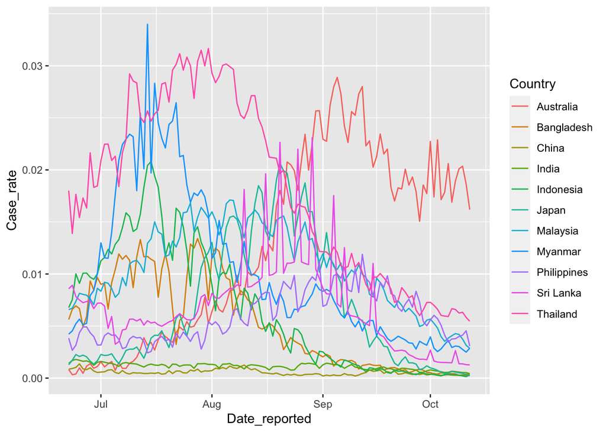

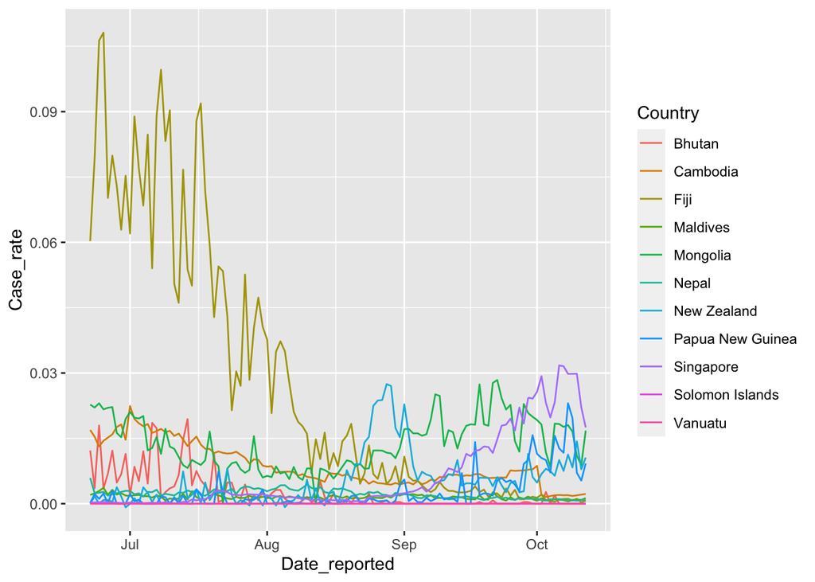

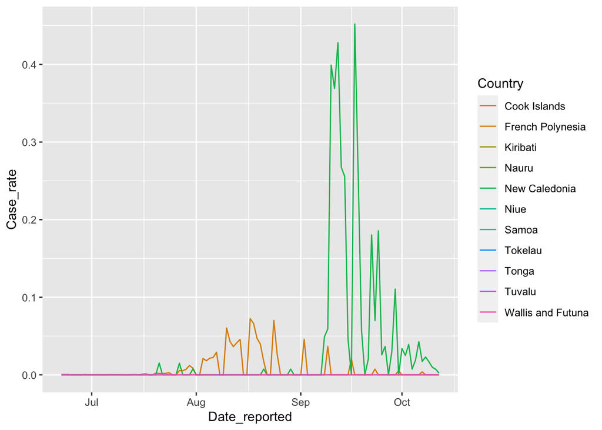

We can already see a major impact of population values on the values.In general, we see a decreasing trend in the case rate as time progresses. This is because vaccination is a cumulative measurement, which are modeled as how much of the population has gotten the vaccine. Vaccination rate in this case, is % of 1 million people who got a vaccine that day. In practice though, we know this is a cumulative rate, as people would not be getting their vaccine daily like a vitamin.

# Ananlysis

```
##                 Df  Sum Sq   Mean Sq F value  Pr(>F)
## Country         10 0.02857 0.0028571  100.36 < 2e-16 ***
## Date_reported    1 0.00216 0.0021564   75.74 < 2e-16 ***
## Vaccinated       1 0.00031 0.0003083   10.83 0.00103 **
## Residuals     1230 0.03502 0.0000285
## ---
## Signif. codes:  0 '***' 0.001 '**' 0.01 '*' 0.05 '.' 0.1 ' ' 1
```

Looking at the summary of the model using country, date, and the vaccination status, we can sense that the vaccination rate is a very important parameter of the model, as the ANOVA table is showing that the variable itself is a significant value at significance alpha = 0.01. This means that if we had not considered the vaccination rate as an important variable in the model, we would see the given data in the extreme 1% of the graph. This reasoning is what makes the data so significant.

In fact, this is even more highlighted when we have a small population for the country:

```
##                Df Sum Sq Mean Sq F value   Pr(>F)
## Country         3 0.0773 0.02575   13.63  1.6e-08 ***
## Date_reported   1 0.0248 0.02476   13.10 0.000329 ***
## Vaccinated      1 0.0426 0.04256   22.52  2.8e-06 ***
## Residuals     446 0.8428 0.00189
## ---
## Signif. codes:  0 '***' 0.001 '**' 0.01 '*' 0.05 '.' 0.1 ' ' 1
## 791 observations deleted due to missingness
```

# Discussion

# Acknowledgement

Vaccination data –> Our World In Data Dataset Country populations –> population 2021. Sort based on first result, mainly from Statista.

Asked Daniel Wallace feedback on project.

# Appendix

For reference, this is the code I used:

```r
knitr::opts_chunk$set(echo = FALSE)
#libraries:
library(formatR)
library(knitr)
library(tidyverse)
library(gridExtra)
library(scales)
library(lubridate)
library(ggplot2)
#First working with the raw WHO COVID data:
raw_dat <- read_csv("https://covid19.who.int/WHO-COVID-19-global-data.csv")
c1 = raw_dat[which(!is.na(raw_dat$Country_code)),c("Date_reported", "New_cases", "Cumulative_cases",  "New_deaths", "Country" , "WHO_region")]

#getting the proper regions in the WHO set
c2 = c1[c1$WHO_region %in% c("SEARO","WPRO"), ]
# Sorting further into only keeping countries that are the same in both data sets
notcount = c("Democratic People's Republic of Korea", "Timor-Leste", "American Samoa", "Brunei Darussalam", "Guam", "Lao People's Democratic Republic", "Marshall Islands","Micronesia (Federated States of)", "Northern Mariana Islands (Commonwealth of the)", "Palau", "Pitcairn Islands", "Republic of Korea", "Viet Nam")

#Removing NA values
covid =c2[!(c2$Country %in% notcount), ]
x = data.frame(matrix(c(colnames(covid)), nrow = 2, byrow = TRUE))
colnames(x) = c("", "", "")
x
# Now working on the Vaccine data
vaccine = read.csv("daily-covid-vaccination-doses-per-capita.csv")

#Getting the column names correct in the table
vaccine_countries = vaccine[vaccine$Entity %in% c(unique(covid$Country)), c("Entity", "Day", "new_vaccinations_smoothed_per_million")]
colnames(vaccine_countries)[colnames(vaccine_countries) == 'new_vaccinations_smoothed_per_million'] <- 'Vaccinated'
colnames(vaccine_countries)[colnames(vaccine_countries) ==  'Entity'] <- 'Country'
colnames(vaccine_countries)[colnames(vaccine_countries) == 'Day'] <-  'Date_reported'


# now merging the data based on the date and the country and the date for which the counts were reported
merged3 = merge(covid, vaccine_countries, by = c("Country", "Date_reported") , all.x = FALSE)
merged2 = merged3[, c("Country", "Date_reported", "Vaccinated", "New_cases", "Cumulative_cases")]
# Restricting to the dates we want to analyze in (between ):


# creating variable measuring the case rate per day for each day for each country
merged2$Case_rate = merged2$New_cases / merged2$Cumulative_cases

y = data.frame(matrix(c(colnames(merged2)), nrow = 2, byrow = TRUE))
colnames(y) = c("", "", "")
y



# now to sort the data based on the groupings on population
## making vectors denoting the groupings first
highpopcountries = c("Australia", "Bangladesh", "China", "India", "Indonesia", "Japan", "Malaysia", "Myanmar", "Philippines", "Sri Lanka", "Thailand")

middlepopcountries = c("Bhutan", "Cambodia", "Fiji", "Maldives", "Mongolia", "Nepal", "New Zealand", "Papua New Guinea", "Singapore", "Solomon Islands", "Vanuatu")

lowpopcountries = c("Cook Islands", "French Polynesia", "Kiribati", "Nauru", "New Caledonia", "Niue", "Samoa", "Tokelau", "Tonga", "Tuvalu", "Wallis and Futuna")

z = data.frame(matrix(c(lowpopcountries, middlepopcountries, highpopcountries), ncol = 3, byrow = FALSE))
colnames(z) = c("Under 300 Thousand People", "300 Thousand - 30 Million People", "Above 30 Million People")
z


merged = filter(merged2, Date_reported>= "2021-06-22", Date_reported<= "2021-10-12")
#Sorting country data on time based on above vector sorting:
highpop =merged[(merged$Country %in% highpopcountries), ]
middlepop =merged[(merged$Country %in% middlepopcountries), ]
lowpop =merged[(merged$Country %in% lowpopcountries), ]

par(mfrow = c(2, 2))
ggplot(data=highpop, mapping=aes(x=Date_reported, y=Case_rate, color = Country)) +
  geom_line()

ggplot(data=middlepop, mapping=aes(x=Date_reported, y=Case_rate, color = Country)) +
  geom_line()

ggplot(data=lowpop, mapping=aes(x=Date_reported, y=Case_rate, color = Country)) +
  geom_line()

model1 = aov(Case_rate~Country+Date_reported + Vaccinated, data=highpop)
summary(model1)
model2 = aov(Case_rate~Country+Date_reported + Vaccinated, data=lowpop)
summary(model2)
sessionInfo()
```